# Matemáticas 11° - Segundo Periodo 2023

Informe profesional de evaluación

ICFES

Instituto Colombiano para la Evaluación de la Educación

14 de enero de 2025

# 1 Pregunta 01

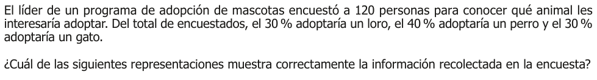

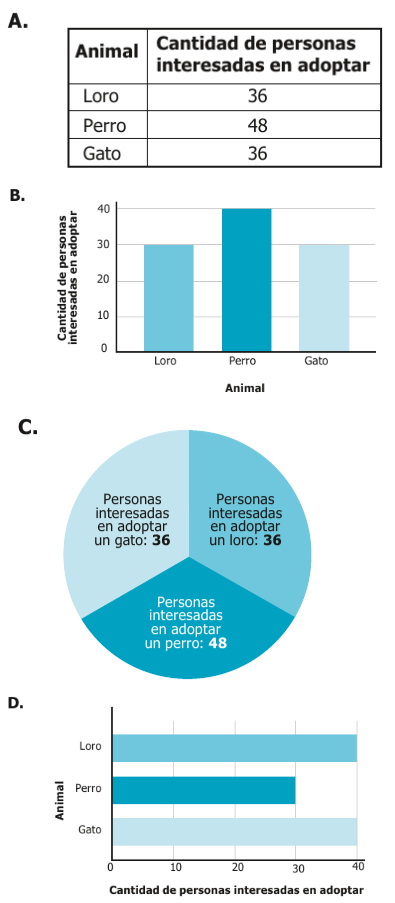

## 1.1 Análisis

La encuesta realizada a 120 personas revela que:

- 30% de las personas (36 personas) están interesadas en adoptar un loro.
- 40% de las personas (48 personas) están interesadas en adoptar un perro.
- 30% de las personas (36 personas) están interesadas en adoptar un gato.

### 1.1.1 **Respuesta:** La opción correcta es **A**.

### 1.1.2 Análisis de la Pregunta 2023-Matematicas-11-2-01, según SABER 11 ICFES

## 1.2 Características de la Pregunta

- Nivel de Desempeño: 2
- Competencia: Interpretación y Representación
  - Afirmación: Comprende y transforma la información cuantitativa y esquemática presentada en distintos formatos
  - Evidencia: Da cuenta de las características básicas de la información presentada en diferentes formatos como series, gráficas, tablas y esquemas
- Componente: Aleatorio
- Estándar Asociado: Interpreto, produzco y comparo representaciones gráficas adecuadas para presentar diversos tipos de datos (diagramas de barras, diagramas circulares)
- ¿Qué evalúa?: La capacidad de identificar la representación gráfica que corresponde correctamente a un conjunto de datos presentados en forma verbal

## 1.3 Solución y Justificación

La información dada establece que de 120 personas encuestadas:

- $30\% = 36$ personas adoptarían un loro
- $40\% = 48$ personas adoptarían un perro
- $30\% = 36$ personas adoptarían un gato

La opción A presenta una tabla que muestra exactamente estos valores numéricos de forma clara y ordenada, siendo la representación más precisa y directa de los datos.

Respuesta correcta: A

## 1.5 Contenidos Matemáticos Curriculares

- Estadística
- Período 1
  - Diferentes tipos de representación
    - Tablas univariadas
    - Diagrama de barras individuales
    - Diagrama circular

## 1.6 Clasificación

- Genérico: Sí
- Eje Axial Disciplinar: Univariadas - Interpretación de tablas y barras elementales
- Tarea: Identificar la representación gráfica que corresponde correctamente a un conjunto de datos presentados textualmente
- Grado sugerido: 7°

# 2 Análisis de Resultados

## 2.1 Competencia 1: Pensamiento Numérico

# 3 Pregunta 02

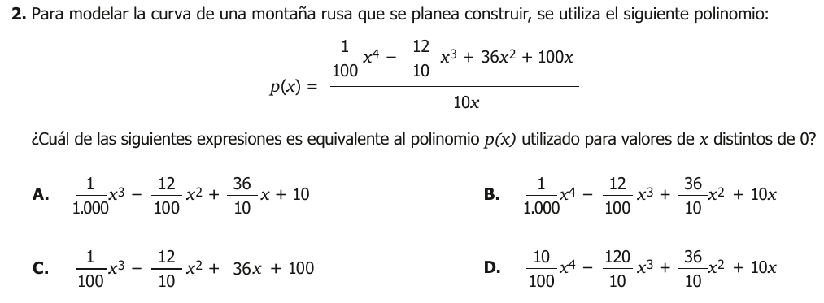

## 3.1 Análisis

Para determinar cuál de las expresiones es equivalente al polinomio $p(x)$ dado para valores de $x$ distintos de 0, debemos simplificar el polinomio original y compararlo con las opciones proporcionadas.

El polinomio original es:

$$p(x) = \frac{\frac{1}{100} x^4 -
\frac{12}{10} x^3 + 36x^2 + 100x}{10x}$$

Vamos a simplificar esta expresión paso a paso.

1. **Simplificar el numerador y el denominador:**

   El numerador es:

   $$\frac{1}{100} x^4 - \frac{12}{10} x^3 +
   36x^2 + 100x$$

   El denominador es:

   $$10x$$
2. **Dividir cada término del numerador por el denominador:**

   $$p(x) = \frac{\frac{1}{100} x^4}{10x} - \frac{\frac{12}{10} x^3}{10x} +
   \frac{36x^2}{10x} + \frac{100x}{10x}$$
3. **Simplificar cada término:**

   $$\frac{\frac{1}{100} x^4}{10x} = \frac{1}{1000} x^3$$

   $$\frac{\frac{12}{10} x^3}{10x} = \frac{12}{100} x^2 = \frac{3}{25} x^2$$

   $$\frac{36x^2}{10x} = \frac{36}{10} x = 3.6x$$

   $$\frac{100x}{10x} = 10$$
4. **Combinar los términos simplificados:**

   $$p(x) = \frac{1}{1000} x^3 - \frac{3}{25} x^2 + 3.6x + 10$$
5. **Convertir las fracciones a decimales para facilitar la comparación:**

   $$\frac{1}{1000} = 0.001$$

   $$\frac{3}{25} = 0.12$$

   Por lo tanto, la expresión simplificada es:

   $$p(x) = 0.001x^3 - 0.12x^2 + 3.6x + 10$$
6. **Comparar con las opciones dadas:**
   - **A.** $\frac{1}{1.000} x^3 - \frac{12}{100} x^2 + \frac{36}{10} x + 10$
   - **B.** $\frac{1}{1.000} x^4 - \frac{12}{100} x^3 + \frac{36}{10} x^2 + 10x$
   - **C.** $\frac{1}{100} x^3 - \frac{12}{10} x^2 + 36x + 100$
   - **D.** $\frac{10}{100} x^4 - \frac{120}{10} x^3 + \frac{36}{10} x^2 + 10x$

   La opción correcta es la **A**, ya que coincide con la expresión simplificada:

   $$p(x) = \frac{1}{1.000} x^3 - \frac{12}{100} x^2 + \frac{36}{10} x + 10$$

### 3.1.1 Conclusión

La opción correcta es la **A**.

### 3.1.2 Análisis de la Pregunta 2023-Matematicas-11-2-02, según SABER 11 ICFES

- Nivel de Desempeño: 4
- Competencia: Interpretación y Representación
  - Afirmación: Comprende y transforma la información cuantitativa y esquemática presentada en distintos formatos
  - Evidencia: Transforma la representación de una o más piezas de información
- Componente: Numérico-Variacional
- Estándar Asociado: Utilizo las técnicas de aproximación en procesos infinitos numéricos.
- ¿Qué evalúa?: La capacidad para simplificar expresiones algebraicas racionales y determinar expresiones equivalentes.
- Respuesta Correcta: A
- Justificación: Para encontrar la expresión equivalente, debemos simplificar $p(x)$:
1. El polinomio original es: $p(x) = \frac{\frac{1}{100}x^4 - \frac{12}{10}x^3 + 36x^2 + 100x}{10x}$
2. Simplificando término a término:
- $\frac{\frac{1}{100}x^4}{10x} = \frac{1}{1000}x^3$
- $-\frac{\frac{12}{10}x^3}{10x} = -\frac{12}{100}x^2$
- $\frac{36x^2}{10x} = \frac{36}{10}x$
- $\frac{100x}{10x} = 10$
3. Por lo tanto: $p(x) = \frac{1}{1000}x^3 - \frac{12}{100}x^2 + \frac{36}{10}x + 10$

Esta expresión coincide con la opción A.

- Distractores:
  - B: No realiza la división por 10x correctamente
  - C: Usa denominadores incorrectos
  - D: Multiplica en lugar de dividir por 10x
- Contenidos Matemáticos Curriculares:
  - Álgebra y Cálculo
  - Período: 2
    - Álgebra
      - Expresiones algebraicas
      - Operaciones con expresiones algebraicas
- No genérico
- Eje Axial Disciplinar: Eje 3 (Términos Semejantes, Factorización Básica: Álgebra)
- Tarea: Simplificar una expresión algebraica racional para determinar una expresión equivalente
- Grado: 11°

## 3.2 Competencia 2: Pensamiento Geométrico

# 4 Pregunta 03

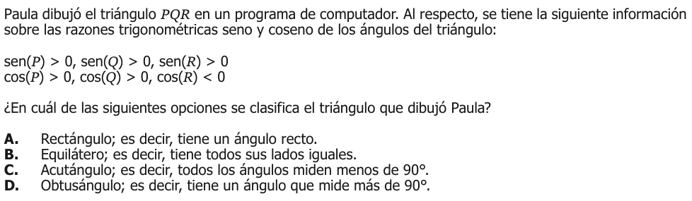

## 4.1 Análisis

Paula dibujó un triángulo PQR, y se proporciona la siguiente información sobre las razones trigonométricas de sus ángulos:

- $\sin(P) > 0$, $\sin(Q) > 0$, $\sin(R) > 0$
- $\cos(P) > 0$, $\cos(Q) > 0$, $\cos(R) < 0$
1. **Seno positivo:**  
   El seno es positivo para ángulos entre 0° y 180°, lo cual es siempre cierto en un triángulo.
2. **Coseno positivo y negativo:**
   - $\cos(P) > 0$ y $\cos(Q) > 0$ indican que ambos ángulos $P$ y $Q$ son agudos (menos de 90°).
   - $\cos(R) < 0$ implica que el ángulo $R$ es obtuso (más de 90°).

### 4.1.1 Conclusión:

Dado que la suma de los ángulos en un triángulo es 180°, si $R$ es obtuso, entonces $P$ y $Q$ deben ser agudos. Por lo tanto, el triángulo tiene un ángulo obtuso y se clasifica como **obtusángulo**.

La opción correcta es:

**D. Obtusángulo; es decir, tiene un ángulo que mide más de 90°.**

### 4.1.2 Análisis de la Pregunta 2023-Matematicas-11-2-03, según SABER 11 ICFES

# 5 Análisis Pregunta Matemáticas

- Nivel de Desempeño: 3
- Competencia: Argumentación
  - Aprendizaje: Valida procedimientos y estrategias matemáticas utilizadas para dar solución a problemas.
  - Evidencia: Plantea afirmaciones que sustentan o refutan una interpretación dada a la información disponible en el marco de la solución de un problema.
- Componente: Geométrico-Métrico
- Estándar Asociado: Uso argumentos geométricos para resolver y formular problemas en contextos matemáticos y en otras ciencias.
- ¿Qué evalúa?: La capacidad de clasificar un triángulo según sus ángulos usando información sobre razones trigonométricas.
- Respuesta Correcta: D
- Justificación: Dado que $\cos(R) < 0$, el ángulo R debe ser obtuso (mayor a 90°), mientras que P y Q son agudos pues tienen coseno positivo. Por lo tanto, el triángulo es obtusángulo.
- Distractores:
  - A: Confunde las condiciones del coseno negativo con ángulo recto
  - B: No relaciona la información trigonométrica con los tipos de triángulos
  - C: Interpreta erróneamente que cosenos positivos implican todos los ángulos agudos
- Contenidos Matemáticos Curriculares:
  - Geometría
  - Período: 1
    - Teoría del ángulo (Clases, ángulos entre rectas paralelas)
- No genérico
- Eje Axial Disciplinar: Geometría del triángulo I
- Tarea: Clasificar un triángulo según sus ángulos a partir de información sobre los signos de las razones trigonométricas de sus ángulos.
- Grado: 10°

## 5.1 Competencia 3: Pensamiento Métrico

# 6 Pregunta 04

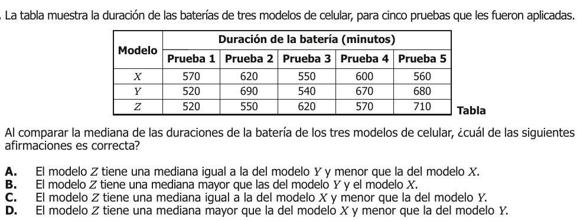

## 6.1 Análisis

La tabla muestra la duración de las baterías de tres modelos de celulares (X, Y y Z) en cinco pruebas diferentes. La tarea es comparar las medianas de las duraciones de las baterías y determinar cuál de las afirmaciones es correcta.

### 6.1.1 Paso 1: Ordenar los datos para cada modelo

- **Modelo X:** 570, 620, 550, 600, 560  
  Ordenados: 550, 560, 570, 600, 620  
  Mediana: 570 minutos
- **Modelo Y:** 520, 690, 540, 670, 680  
  Ordenados: 520, 540, 670, 680, 690  
  Mediana: 670 minutos
- **Modelo Z:** 520, 550, 620, 570, 710  
  Ordenados: 520, 550, 570, 620, 710  
  Mediana: 570 minutos

### 6.1.2 Paso 2: Comparar las medianas

- Mediana de X: 570 minutos
- Mediana de Y: 670 minutos
- Mediana de Z: 570 minutos

### 6.1.3 Paso 3: Evaluar las opciones

- **Opción A:** Incorrecta. Z (570) no tiene la misma mediana que Y (670), y es menor que X (570), pero X y Z tienen la misma mediana.
- **Opción B:** Incorrecta. Z (570) no tiene una mediana mayor que Y (670) ni que X (570).
- **Opción C:** Correcta. Z (570) tiene la misma mediana que X (570) y ambas son menores que Y (670).
- **Opción D:** Incorrecta. Z (570) no tiene una mediana mayor que X (570), ambas son iguales.

### 6.1.4 Conclusión

La afirmación correcta es la **Opción C**.

### 6.1.5 Respuesta final

La opción correcta es **C.** El modelo Z tiene una mediana igual a la del modelo X y menor que la del modelo Y.

### 6.1.6 Análisis de la Pregunta 2023-Matematicas-11-2-04, según SABER 11 ICFES

## 6.2 Nivel de Desempeño

2

## 6.3 Competencia

Interpretación y Representación

- Afirmación: Comprende y transforma la información cuantitativa y esquemática presentada en distintos formatos.
- Evidencia: Da cuenta de las características básicas de la información presentada en diferentes formatos como series, gráficas, tablas y esquemas.

## 6.4 Componente

Aleatorio

## 6.5 Estándar Asociado

Interpreto nociones básicas relacionadas con el manejo de información como población, muestra, variable aleatoria, distribución de frecuencias, parámetros y estadígrafos.

## 6.6 ¿Qué evalúa?

La capacidad del estudiante para calcular e interpretar medidas de tendencia central (mediana) a partir de datos presentados en una tabla y realizar comparaciones entre estos valores.

## 6.7 Respuesta Correcta y Justificación

La respuesta correcta es C.

Para cada modelo, ordenando los datos de menor a mayor:

Modelo X: $550, 560, \mathbf{570}, 600, 620$ → Mediana = $570$

Modelo Y: $520, 540, \mathbf{670}, 680, 690$ → Mediana = $670$

Modelo Z: $520, 550, \mathbf{570}, 620, 710$ → Mediana = $570$

Por lo tanto:

- Mediana Z = Mediana X = $570$
- Mediana Y = $670$ > Mediana Z

## 6.8 Motivos de las Opciones Incorrectas

- A: Confunde las relaciones, pues Z no tiene mediana igual a Y
- B: Invierte las relaciones de orden entre las medianas
- D: Confunde la relación entre Z y X, que son iguales

## 6.9 Contenidos Matemáticos Curriculares

- Estadística
  - Período 2
    - Medidas de tendencia central
      - Mediana

## 6.10 ¿Genérico o No genérico?

Genérico

## 6.11 Eje Axial Disciplinar

Eje 4: Descriptivos - Tendencia Central

## 6.12 Tarea

Calcular y comparar las medianas de tres conjuntos de datos presentados en una tabla.

## 6.13 Grado

10° - 11°

## 6.14 Competencia 4: Pensamiento Aleatorio

# 7 Pregunta 05

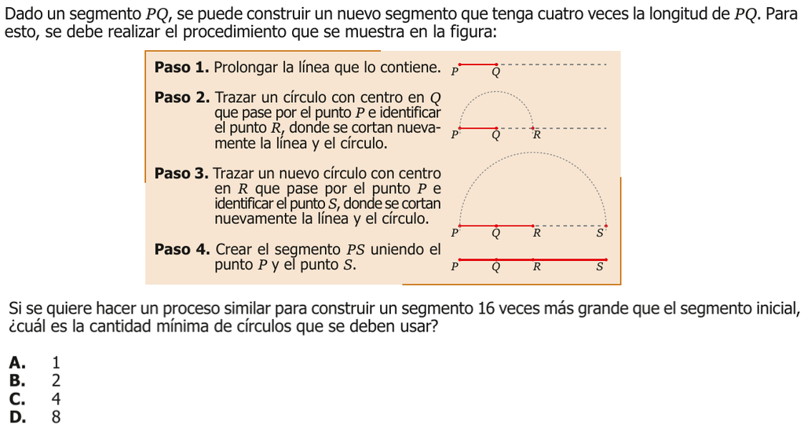

## 7.1 Análisis

Dado un segmento PQ, el objetivo es construir un nuevo segmento que sea 16 veces más largo que PQ, siguiendo un procedimiento similar al que se usa para construir un segmento 4 veces más largo.

### 7.1.1 Paso a paso:

1. **Entendiendo el procedimiento inicial**: El proceso para construir un segmento 4 veces más largo que PQ probablemente involucra el uso de círculos para duplicar sucesivamente la longitud. Por ejemplo, un círculo permite duplicar la longitud, y repetir este proceso con otro círculo duplica nuevamente el segmento, alcanzando así una longitud 4 veces mayor.
2. **Escalando a 16 veces la longitud**: La longitud 16PQ es equivalente a realizar cuatro veces el proceso de duplicación (ya que 16 = 2^4). Si cada círculo permite duplicar la longitud, entonces serán necesarios cuatro círculos para llegar de PQ a 16PQ.
3. **Verificación de eficiencia**: Se consideraron otras posibilidades, como el uso de círculos para construir triángulos semejantes o métodos más avanzados. Sin embargo, no se encontró una forma más eficiente que reduzca el número de círculos necesario.

### 7.1.2 Conclusión:

La cantidad mínima de círculos necesaria para construir un segmento 16 veces más largo que PQ es **cuatro** (C).

### 7.1.3 Análisis de la Pregunta 2023-Matematicas-11-2-05, según SABER 11 ICFES

- Nivel de Desempeño: 3
- Competencia: Argumentación
  - Aprendizaje: Valida procedimientos y estrategias matemáticas utilizadas para dar solución a problemas
  - Evidencia: Argumenta a favor o en contra de un procedimiento para resolver un problema a la luz de criterios presentados o establecidos
- Componente: Geométrico-Métrico
- Estándar Asociado: Construyo y descompongo figuras y sólidos a partir de condiciones dadas
- ¿Qué evalúa?: La capacidad de analizar un proceso geométrico de construcción y extenderlo a un caso más complejo

## 7.2 Solución

La respuesta correcta es C. 4 círculos

### 7.2.2 Distractores

- A (1 círculo): Insuficiente, solo permitiría duplicar una vez
- B (2 círculos): Solo alcanzaría para cuadruplicar el segmento
- D (8 círculos): Excesivo, produciría un segmento de $2^8 = 256$ veces el original

## 7.3 Características

- Contenidos Matemáticos Curriculares:
  - Geometría
  - Período 2
    - Polígonos y Transformaciones en el Plano
      - Homotecia
- No genérico
- Eje Axial Disciplinar: Traslación, Rotación, Reflexión, Homotecias: Movimientos en el plano (x,y)
- Tarea: Determinar la cantidad mínima de círculos necesarios para multiplicar por 16 la longitud de un segmento usando un método geométrico de duplicación sucesiva
- Grado: 9°

## 7.4 Competencia 5: Pensamiento Variacional

# 8 Pregunta 06

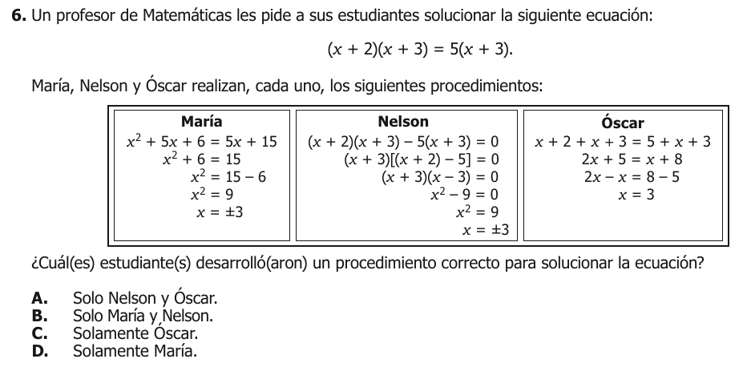

## 8.1 Análisis

## 8.2 Evaluación Sistemática

### 8.2.1 1. Análisis de la Ecuación Original

La ecuación que deben resolver es: (x + 2)(x + 3) = 5(x + 3)

### 8.2.2 2. Evaluación de Cada Procedimiento

#### 8.2.2.1 María

```
x² + 5x + 6 = 5x + 15       # Desarrolla el producto del lado izquierdo
x² + 6 = 15                 # Agrupa términos semejantes
x² = 15 - 6                 # Despeja x²
x² = 9                      # Simplifica
x = ±3                      # Obtiene las raíces
```

*Procedimiento correcto y completo*

#### 8.2.2.2 Nelson

```
(x + 2)(x + 3) - 5(x + 3) = 0   # Pasa todo a un lado de la igualdad
(x + 3)[(x + 2) - 5] = 0        # Factoriza el término común (x + 3)
(x + 3)(x - 3) = 0              # Simplifica
x² - 9 = 0                      # Multiplica los términos
x = ±3                          # Obtiene las raíces
```

*Procedimiento correcto y completo*

#### 8.2.2.3 Óscar

```
x + 2 + x + 3 = 5 + x + 3       # Error: no desarrolla el producto
2x + 5 = x + 8                  # Agrupa términos
2x - x = 8 - 5                  # Despeja x
x = 3                           # Obtiene solo una raíz
```

*Procedimiento incorrecto*

### 8.2.3 3. Conclusión

La respuesta correcta es la opción **B: Solo María y Nelson**.

Justificación: - María y Nelson obtienen correctamente ambas soluciones (x = 3 y x = -3) - Sus procedimientos son algebraicamente válidos - Óscar comete un error fundamental al no desarrollar el producto (x + 2)(x + 3) - Óscar solo obtiene una solución parcial y por un método incorrecto

## 8.3 Verificación

Para x = 3: - (3 + 2)(3 + 3) = 5(3 + 3) - (5)(6) = 5(6) - 30 = 30

Para x = -3: - (-3 + 2)(-3 + 3) = 5(-3 + 3) - (-1)(0) = 5(0) - 0 = 0

Las soluciones x = 3 y x = -3 son correctas, confirmando que María y Nelson llegaron al resultado correcto por métodos válidos.

### 8.3.1 Análisis de la Pregunta 2023-Matematicas-11-2-06, según SABER 11 ICFES

### 8.3.2 Nivel de Desempeño: 3

### 8.3.3 Competencia: Argumentación

- Aprendizaje: Valida procedimientos y estrategias matemáticas utilizadas para dar solución a problemas.
- Evidencia: Argumenta a favor o en contra de un procedimiento para resolver un problema a la luz de criterios presentados o establecidos.

### 8.3.4 Componente: Numérico-Variacional

### 8.3.5 Estándar Asociado:

Justifico procedimientos algebraicos utilizados en la transformación de expresiones algebraicas y verifico relaciones entre expresiones algebraicas equivalentes.

### 8.3.6 ¿Qué evalúa?

La capacidad para validar diferentes procedimientos algebraicos en la solución de una ecuación cuadrática.

### 8.3.7 Respuesta Correcta: B (Solo María y Nelson)

### 8.3.8 Justificación:

- María desarrolla correctamente:
  - Expande $(x + 2)(x + 3) = 5(x + 3)$ obteniendo $x^2 + 5x + 6 = 5x + 15$
  - Agrupa términos semejantes: $x^2 + 6 = 15$
  - Resuelve para $x = \pm 3$
- Nelson aplica factorización:
  - Reescribe como $(x + 3)[(x + 2) - 5] = 0$
  - Obtiene $(x + 3)(x - 3) = 0$
  - Resuelve para $x = \pm 3$
- Óscar comete error al:
  - No multiplicar los términos $(x + 2)(x + 3)$
  - Suma incorrectamente los términos lineales
  - Obtiene solo una solución parcial

### 8.3.9 Distractores:

A. Confunde procedimientos válidos con inválidos C. y D. Identifica solo un procedimiento como correcto cuando hay dos

### 8.3.10 Contenidos Matemáticos Curriculares:

- Álgebra y Cálculo
- Período 2
  - Álgebra
    - Expresiones algebraicas
    - Operaciones con expresiones algebraicas

### 8.3.11 Tipo: No genérico

### 8.3.12 Eje Axial Disciplinar:

Eje 3 - Términos Semejantes, Factorización Básica: Álgebra

### 8.3.13 Tarea:

Evaluar la validez de tres procedimientos diferentes para resolver una ecuación cuadrática.

### 8.3.14 Grado: 9° - 11°

## 8.4 Competencia 6: Aplicaciones Integradas

# 9 Pregunta 07

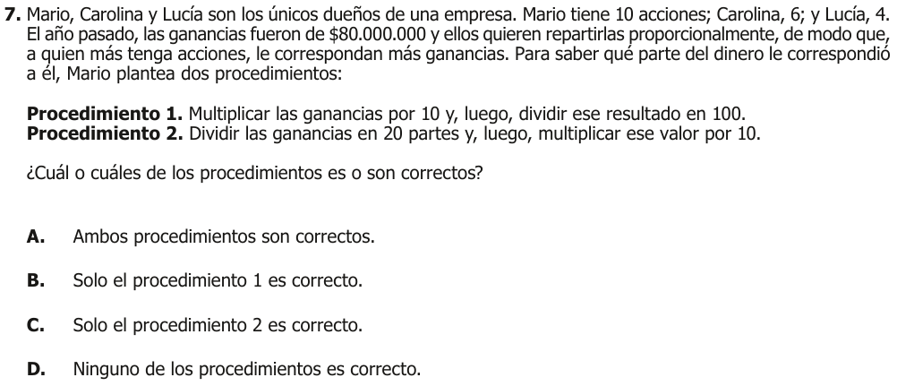

## 9.1 Análisis

Identifiquemos los elementos clave del problema:

- Total de acciones: 10 + 6 + 4 = 20 acciones
- Ganancias totales: $80.000.000
- Mario tiene 10 acciones (50%)
- Carolina tiene 6 acciones (30%)
- Lucía tiene 4 acciones (20%)

## 9.2 Evaluación de Procedimientos

### 9.2.1 Procedimiento 1:

Multiplicar ganancias por 10 y dividir entre 100:

- $80.000.000 × 10 ÷ 100 = $8.000.000

### 9.2.2 Procedimiento 2:

Dividir ganancias entre 20 y multiplicar por 10:

- $80.000.000 ÷ 20 × 10 = $40.000.000

## 9.3 Verificación Matemática

Para determinar la parte correcta de Mario (10 acciones de 20 totales):

- Fracción correspondiente: 10/20 = 1/2 = 50%
- Monto correcto: $80.000.000 × 50% = $40.000.000

## 9.4 Conclusión

La respuesta correcta es C: Solo el procedimiento 2 es correcto.

### 9.4.1 Justificación:

1. El procedimiento 1 resulta en $8.000.000, que es solo el 10% de las ganancias totales, muy por debajo del 50% que le corresponde a Mario.
2. El procedimiento 2 resulta en $40.000.000, que es exactamente el 50% de las ganancias totales, correspondiente a las 10 acciones de Mario de un total de 20.

## 9.5 Verificación Final

- Procedimiento 2: $80.000.000 ÷ 20 × 10 = $40.000.000
- Este resultado coincide con el cálculo directo del 50% de $80.000.000
- Confirma la proporcionalidad requerida según el número de acciones

Por lo tanto, solo el procedimiento 2 proporciona el resultado correcto para calcular la parte correspondiente a Mario.

### 9.5.1 Análisis de la Pregunta 2023-Matematicas-11-2-07, según SABER 11 ICFES

- Nivel de Desempeño: 3
- Competencia: Formulación y Ejecución
  - Aprendizaje: Frente a un problema que involucre información cuantitativa, plantea e implementa estrategias que lleven a soluciones adecuadas.
  - Evidencia: Ejecuta un plan de solución para un problema que involucra información cuantitativa o esquemática.
- Componente: Numérico-Variacional
- Estándar Asociado: Resuelvo y formulo problemas en situaciones de proporcionalidad directa, inversa y producto de medidas.
- ¿Qué evalúa?: La capacidad para validar procedimientos matemáticos que involucran proporcionalidad directa en un contexto financiero.
- Respuesta Correcta: C
- Justificación: El procedimiento 2 es correcto porque:

  $\text{Ganancia de Mario} = \frac{\text{Ganancias totales}}{\text{Total acciones}} \times \text{Acciones de Mario}$

  $\text{Ganancia de Mario} = \frac{\$80.000.000}{20} \times 10 = \$40.000.000$
- Motivos de opciones incorrectas:
  - A: Asume que ambos procedimientos dan el mismo resultado
  - B: El procedimiento 1 calcula el 10% en lugar del 50% requerido
  - D: No reconoce que el procedimiento 2 es matemáticamente válido
- Contenidos Matemáticos Curriculares:
  - Álgebra y Cálculo
  - Período 1
    - Números y Operaciones
      - Números racionales (fracciones, decimales y porcentajes)
- Genérico: Sí
- Eje Axial Disciplinar: Eje 3 - Función Lineal, Generalizaciones y Grado 2
- Tarea: Validar procedimientos aritméticos para calcular una proporción directa en un contexto de repartición de ganancias.
- Grado: 7° - 11°

# 10 Pregunta 08

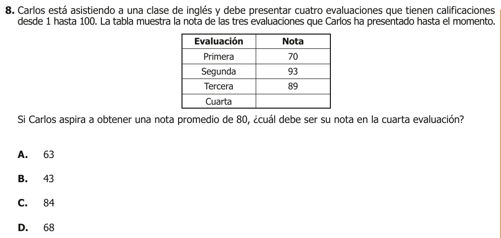

## 10.1 Análisis

Para encontrar la nota necesaria en la cuarta evaluación, debemos: * Identificar el promedio objetivo: 80 * Reconocer las notas existentes: 70, 93, 89 * Comprender que necesitamos que el promedio de las 4 notas sea 80

## 10.2 Desarrollo Estratégico

### 10.2.1 1. Planteamiento de la Ecuación

Para un promedio de 80, sabemos que:

```
(70 + 93 + 89 + x) ÷ 4 = 80
```

donde x es la nota que necesitamos encontrar.

### 10.2.2 2. Resolución Algebraica

```
70 + 93 + 89 + x = 80 × 4
70 + 93 + 89 + x = 320
               x = 320 - (70 + 93 + 89)
               x = 320 - 252
               x = 68
```

### 10.2.3 3. Verificación

Comprobemos que 68 es la respuesta correcta:

```
(70 + 93 + 89 + 68) ÷ 4 = 320 ÷ 4 = 80
```

## 10.3 Conclusión

La respuesta correcta es D. 68

## 10.4 Justificación

- Carlos necesita obtener un 68 en su cuarta evaluación para alcanzar exactamente un promedio de 80.
- Este resultado es lógico porque:
  - Es una nota posible dentro del rango (1-100)
  - Es menor que sus últimas dos notas (93 y 89)
  - Compensa la nota más baja (70) para lograr el promedio deseado

## 10.5 Recomendación Pedagógica

Este ejercicio demuestra la importancia de:

1. Traducir el problema a lenguaje algebraico
2. Resolver paso a paso la ecuación
3. Verificar que la solución cumple con todas las condiciones del problema

## 10.6 Análisis de la Pregunta 2023-Matematicas-11-2-08, según SABER 11 ICFES

- Nivel de Desempeño: 3
- Competencia: Formulación y Ejecución
  - Aprendizaje: Frente a un problema que involucre información cuantitativa, plantea e implementa estrategias que lleven a soluciones adecuadas
  - Evidencia: Ejecuta un plan de solución para un problema que involucra información cuantitativa o esquemática
- Componente: Numérico-Variacional
- Estándar Asociado: Resuelvo problemas y simplifico cálculos usando propiedades y relaciones de los números reales y de las relaciones y operaciones entre ellos
- ¿Qué evalúa?: La capacidad para plantear y resolver una ecuación lineal que modele una situación de promedio aritmético
- Respuesta Correcta: D (68)
- Justificación:
  - Sea $x$ la nota de la cuarta evaluación
  - El promedio de 80 se expresa como: $\frac{70 + 93 + 89 + x}{4} = 80$
  - Resolviendo: $70 + 93 + 89 + x = 320$
  - Por lo tanto: $x = 320 - 252 = 68$
- Distractores:
  - A (63): Resultado de un cálculo incorrecto al no multiplicar 80 por 4
  - B (43): Error al plantear la ecuación considerando solo tres notas
  - C (84): Confusión al asumir que la nota debe ser mayor que el promedio deseado
- Contenidos Matemáticos Curriculares:
  - Álgebra y Cálculo
  - Período 1
    - Números y Operaciones
      - Operaciones aritméticas
- Genérico: Sí
- Eje Axial Disciplinar: Eje 3 - Función Lineal
- Tarea: Determinar un valor desconocido usando el concepto de promedio aritmético mediante una ecuación lineal
- Grado: 8° - 11°

# 11 Pregunta 09

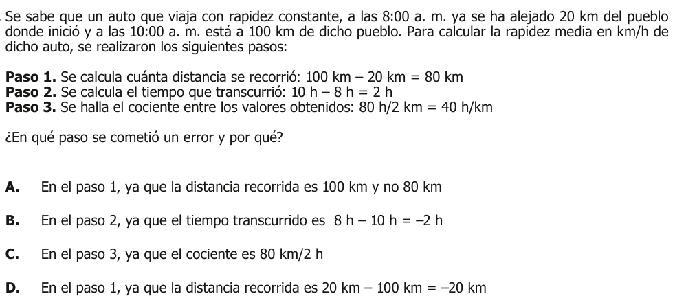

# 12 Análisis detallado del problema

## 12.1 Enunciado

Un auto viaja con rapidez constante. A las **8:00 a. m.** se encuentra a **20 km** del pueblo de partida, y a las **10:00 a. m.** está a **100 km** del mismo pueblo. Se busca calcular la rapidez media del auto en km/h a partir de tres pasos presentados, y determinar si hay errores en el procedimiento.

## 12.4 Conclusión

La **opción correcta** es: **C**.  
El error en el paso 3 radica en la descripción de la unidad como $\text{h/km}$, lo cual es incorrecto; debería ser $\text{km/h}$. Esto refleja una imprecisión en la presentación del resultado final, aunque los cálculos matemáticos sean correctos.

## 12.5 Notas adicionales

La respuesta final, si se redactara correctamente, sería:
$$\text{Rapidez media} = 40 \, \text{km/h}.$$

## 12.6 Análisis de la Pregunta 2023-Matematicas-11-2-09, según SABER 11 ICFES

## 12.7 Nivel de Desempeño

3

## 12.8 Competencia

- Argumentación
  - Afirmación: Valida procedimientos y estrategias matemáticas utilizadas para dar solución a problemas
  - Evidencia: Argumenta a favor o en contra de un procedimiento para resolver un problema a la luz de criterios presentados o establecidos

## 12.9 Componente

Numérico-Variacional

## 12.10 Estándar Asociado

Utilizo las técnicas de aproximación en procesos infinitos numéricos.

## 12.11 ¿Qué evalúa?

La capacidad del estudiante para identificar errores en procedimientos que involucran el cálculo de la rapidez media, incluyendo el manejo correcto de unidades físicas.

## 12.13 Justificación

El error está en el paso 3 porque:

1. La unidad de medida de la rapidez media debe ser km/h (kilómetros por hora)
2. En el procedimiento se expresa incorrectamente como h/km (horas por kilómetro)
3. Aunque el valor numérico 40 es correcto, la unidad está invertida

## 12.14 Distractores

- A: Confunde el desplazamiento total con la posición final
- B: Invierte incorrectamente el orden de la resta en el tiempo
- D: Invierte incorrectamente el orden de la resta en la distancia

## 12.15 Contenidos Matemáticos Curriculares

- Álgebra y Cálculo
- Período 1
  - Números y Operaciones
    - Uso de números y operaciones en la resolución de problemas

## 12.16 ¿Genérico o No genérico?

Genérico

## 12.17 Eje Axial Disciplinar

Eje 3: Funciones I - Función Lineal

## 12.18 Tarea

Validar la coherencia entre las unidades de medida y el significado físico de la rapidez media en un problema de movimiento rectilíneo uniforme.

## 12.19 Grado

11°

# 13 Pregunta 10

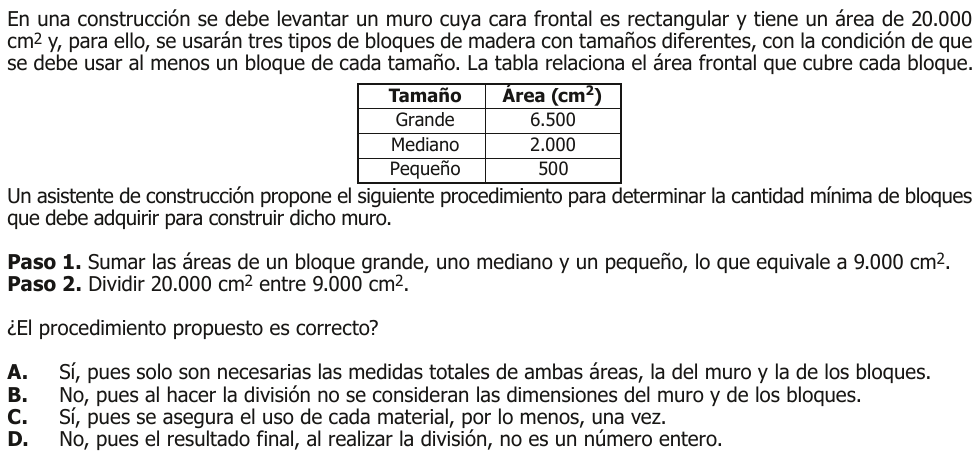

# 14 Análisis detallado del problema

### 14.0.1 Procedimiento Propuesto

1. **Paso 1:** Sumar las áreas de un bloque grande, uno mediano y uno pequeño, lo que equivale a 9.000 cm².
2. **Paso 2:** Dividir 20.000 cm² entre 9.000 cm².

### 14.0.2 Análisis del Procedimiento

1. **Paso 1:**
   - Área de un bloque grande: 6.500 cm²
   - Área de un bloque mediano: 2.000 cm²
   - Área de un bloque pequeño: 500 cm²

   Sumando estas áreas:
   $$6.500 \, \text{cm}^2 + 2.000 \, \text{cm}^2 + 500 \, \text{cm}^2 = 9.000
   \, \text{cm}^2$$
2. **Paso 2:**
   - Dividir el área total del muro (20.000 cm²) entre el área total de los tres bloques (9.000 cm²):
     $$\frac{20.000 \, \text{cm}^2}{9.000 \, \text{cm}^2} \approx 2.22$$

   Este resultado no es un número entero, lo que indica que no se puede cubrir exactamente el muro con bloques enteros de estos tamaños sin dejar espacios o sin cortar bloques.

### 14.0.4 Conclusión

Las opciones correctas son **B** y **D**. Sin embargo, la opción **B** es más completa porque explica que el procedimiento no considera las dimensiones específicas del muro y de los bloques, lo que es crucial para determinar si los bloques pueden cubrir el muro sin dejar espacios.

Por lo tanto, la opción correcta es:

**B. No, pues al hacer la división no se consideran las dimensiones del muro y de los bloques.**

## 14.1 Análisis de la Pregunta 2023-Matematicas-11-2-10, según SABER 11 ICFES

## 14.2 Nivel, Competencia y Componentes

- **Nivel de Desempeño**: 4
- **Competencia**: Argumentación
  - **Afirmación**: Valida procedimientos y estrategias matemáticas utilizadas para dar solución a problemas
  - **Evidencia**: Argumenta a favor o en contra de un procedimiento para resolver un problema a la luz de criterios presentados o establecidos
- **Componente**: Numérico-Variacional
- **Estándar Asociado**: Justifico la pertinencia de utilizar unidades de medida estandarizadas en situaciones tomadas de distintas ciencias.

## 14.3 Análisis de la Pregunta

### 14.3.1 ¿Qué evalúa?

Evalúa la capacidad del estudiante para analizar críticamente un procedimiento propuesto para resolver un problema geométrico que involucra áreas y dimensiones.

### 14.3.2 Respuesta Correcta: B

No, pues al hacer la división no se consideran las dimensiones del muro y de los bloques.

### 14.3.3 Justificación

El procedimiento es incorrecto porque:

1. Solo considera las áreas totales sin tener en cuenta:
   - Las dimensiones específicas del muro (largo y ancho)
   - Las dimensiones de cada tipo de bloque
2. La división $\frac{20.000}{9.000} \approx 2.22$ no garantiza que los bloques puedan cubrir el muro de manera exacta sin dejar espacios.

### 14.3.4 Contenidos Matemáticos Curriculares

- **Categoría**: Geometría
- **Período**: 2
  - Polígonos
    - Área y perímetro
    - Áreas por composición y descomposición

### 14.3.5 Características Adicionales

- **Tipo**: No genérico
- **Eje Axial Disciplinar**: Área, Perímetro, Subconjuntos de Áreas
- **Tarea**: Evaluar la validez de un procedimiento para determinar la cantidad mínima de bloques necesarios para cubrir un área rectangular dada
- **Grado sugerido**: 9° - 11°

# 15 Pregunta 11

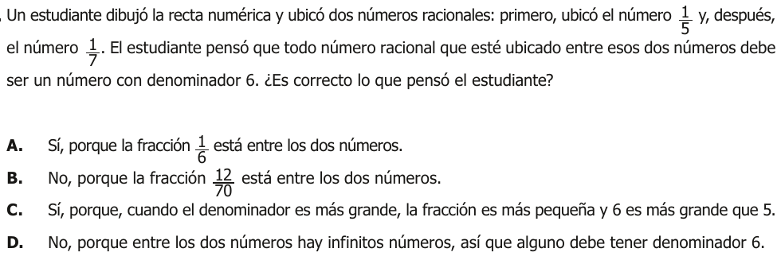

# 16 Análisis detallado del problema

La respuesta correcta es la **B**.

**Explicación detallada:**

El estudiante se equivoca al pensar que todo número racional entre $\frac{1}{7}$ y $\frac{1}{5}$ debe tener denominador 6. Para comprobar esto, podemos buscar un contraejemplo, es decir, un número racional entre $\frac{1}{7}$ y $\frac{1}{5}$ que no tenga denominador 6.

**Paso 1: Comparar las fracciones dadas.**

Para comparar las fracciones y encontrar números entre ellas, es útil tener un denominador común. El mínimo común múltiplo de 7 y 5 es 35.

$\frac{1}{7} = \frac{1 \times 5}{7 \times 5} = \frac{5}{35}$

$\frac{1}{5} = \frac{1 \times 7}{5 \times 7} = \frac{7}{35}$

Ahora vemos que los números racionales que buscamos están entre $\frac{5}{35}$ y $\frac{7}{35}$.

**Paso 2: Analizar las opciones.**

- **Opción A:** Afirma que $\frac{1}{6}$ está entre los dos números. Vamos a comprobarlo. Para comparar $\frac{1}{6}$ con $\frac{1}{7}$ y $\frac{1}{5}$, también podemos usar un denominador común. El mínimo común múltiplo de 7, 5 y 6 es 210. $\frac{1}{7} = \frac{30}{210}$ $\frac{1}{6} = \frac{35}{210}$ $\frac{1}{5} = \frac{42}{210}$ Como $30 < 35 < 42$, entonces $\frac{1}{7} < \frac{1}{6} < \frac{1}{5}$. Si bien $\frac{1}{6}$ está entre los dos números, esto no demuestra que *todos* los números entre ellos deban tener denominador 6.
- **Opción B:** Afirma que $\frac{12}{70}$ está entre los dos números. Vamos a comprobarlo. Primero, simplificamos la fracción $\frac{12}{70}$: $\frac{12}{70} = \frac{12 \div 2}{70 \div 2} = \frac{6}{35}$ Ya habíamos expresado $\frac{1}{7}$ y $\frac{1}{5}$ con denominador 35: $\frac{1}{7} = \frac{5}{35}$ $\frac{1}{5} = \frac{7}{35}$ Como $5 < 6 < 7$, entonces $\frac{5}{35} < \frac{6}{35} < \frac{7}{35}$, lo que significa que $\frac{1}{7} < \frac{12}{70} < \frac{1}{5}$. La fracción $\frac{12}{70}$ (o su forma simplificada $\frac{6}{35}$) está entre los dos números y su denominador (70 o 35) no es 6. Esto demuestra que la suposición del estudiante es incorrecta.
- **Opción C:** Indica que cuando el denominador es más grande, la fracción es más pequeña y 6 es más grande que 5. Si bien la primera parte de la afirmación es correcta (para numeradores positivos iguales), la conclusión no justifica la afirmación del estudiante. La comparación de los denominadores 5 y 6 no prueba que todos los números entre $\frac{1}{7}$ y $\frac{1}{5}$ deban tener denominador 6.
- **Opción D:** Afirma que entre los dos números hay infinitos números, así que alguno debe tener denominador 6. Si bien es cierto que hay infinitos números racionales entre dos racionales cualesquiera, esto no implica que *todos* los números entre ellos deban tener un denominador específico como 6. De hecho, la existencia de infinitos números sugiere que hay muchas más opciones de denominadores.

**Conclusión:**

La opción correcta es la **B** porque proporciona un contraejemplo específico: la fracción $\frac{12}{70}$ está entre $\frac{1}{7}$ y $\frac{1}{5}$, y su denominador no es 6. Esto demuestra que la suposición del estudiante es incorrecta.

## 16.1 Análisis de la Pregunta 2023-Matematicas-11-2-11, según SABER 11 ICFES

- Nivel de Desempeño: 4
- Competencia: Argumentación
  - Afirmación: Valida procedimientos y estrategias matemáticas utilizadas para dar solución a problemas
  - Evidencia: Plantea afirmaciones que sustentan o refutan una interpretación dada a la información disponible en el marco de la solución de un problema
- Componente: Numérico-Variacional
- Estándar Asociado: Justifico la pertinencia de utilizar unidades de medida estandarizadas en situaciones tomadas de distintas ciencias
- ¿Qué evalúa?: La capacidad de refutar una afirmación sobre números racionales usando un contraejemplo específico
- Respuesta Correcta: B, porque proporciona un contraejemplo ($\frac{12}{70}$) que demuestra que no todo número racional entre $\frac{1}{7}$ y $\frac{1}{5}$ debe tener denominador 6
- Distractores:
  - A: Confunde la existencia de un número con denominador 6 entre los dados con la necesidad de que todos tengan ese denominador
  - C: Usa una propiedad válida de fracciones pero llega a una conclusión incorrecta
  - D: Confunde la existencia de infinitos números con la necesidad de tener un denominador específico
- Contenidos Matemáticos Curriculares:
  - Álgebra y Cálculo
  - Período 1
    - Números y Operaciones
      - Números racionales (fracciones, decimales y porcentajes)
- No genérico
- Eje Axial Disciplinar: Eje 3 - Teoría de Números
- Tarea: Refutar una afirmación sobre números racionales mediante la construcción de un contraejemplo
- Grado: 11° (También aplicable desde 8° según los Estándares Básicos de Competencias)

# 17 Pregunta 12

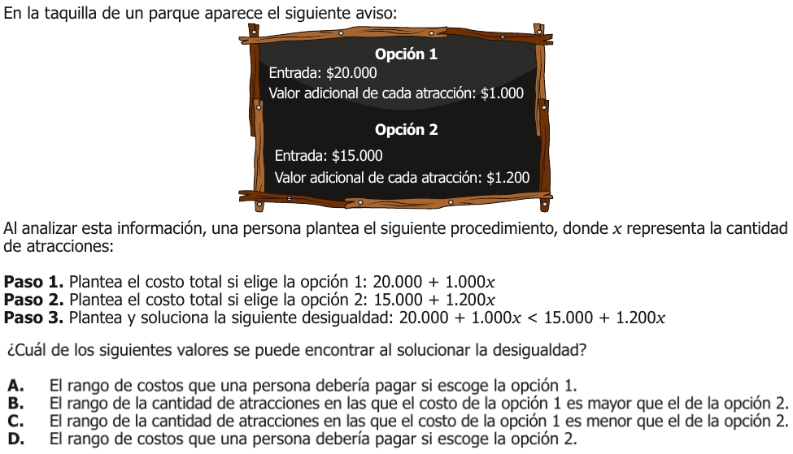

# 18 Análisis detallado del problema

Vamos a analizar la pregunta y la solución paso a paso.

La desigualdad planteada es: 20.000 + 1.000x < 15.000 + 1.200x

Esta desigualdad busca encontrar la condición en la que el costo total de la **Opción 1** es **menor que** el costo total de la **Opción 2**.

Resolvamos la desigualdad:

1. Restamos 1.000x a ambos lados: 20.000 < 15.000 + 0.200x
2. Restamos 15.000 a ambos lados: 5.000 < 0.200x
3. Dividimos ambos lados por 0.200: 5.000 / 0.200 < x 25 < x

La solución a la desigualdad es x > 25.

¿Qué significa esta solución en el contexto del problema?

- **x** representa la cantidad de atracciones.
- La desigualdad se planteó para cuando el costo de la Opción 1 es menor que el costo de la Opción 2.
- La solución x > 25 significa que para cualquier cantidad de atracciones mayor a 25, el costo de la Opción 1 es menor que el costo de la Opción 2.

Ahora, revisemos las opciones de respuesta:

- **A. El rango de costos que una persona debería pagar si escoge la opción 1.** La desigualdad nos ayuda a determinar cuándo la Opción 1 es más barata, pero la solución se refiere directamente a la cantidad de atracciones, no al costo en sí.
- **B. El rango de la cantidad de atracciones en las que el costo de la opción 1 es mayor que el de la opción 2.** La desigualdad está planteada para cuando el costo de la Opción 1 es *menor que* el de la Opción 2. La solución refleja esta condición.
- **C. El rango de la cantidad de atracciones en las que el costo de la opción 1 es menor que el de la opción 2.** Esta opción coincide con nuestra interpretación de la solución x > 25. Indica el rango de cantidad de atracciones para el cual elegir la Opción 1 es más económico.
- **D. El rango de costos que una persona debería pagar si escoge la opción 2.** Al igual que la opción A, la desigualdad ayuda a determinar cuándo la Opción 1 es más barata, y la solución se refiere a la cantidad de atracciones, no al costo de la Opción 2.

Por lo tanto, la respuesta correcta es la **C**. La solución de la desigualdad nos da el rango de la cantidad de atracciones en las que el costo de la opción 1 es menor que el de la opción 2.

## 18.1 Análisis de la Pregunta 2023-Matematicas-11-2-12, según SABER 11 ICFES

**Nivel de Desempeño**: 3

**Competencia**: Interpretación y Representación

- *Afirmación*: Comprende y transforma la información cuantitativa y esquemática presentada en distintos formatos
- *Evidencia*: Da cuenta de las características básicas de la información presentada en diferentes formatos

**Componente**: Numérico-Variacional

**Estándar Asociado**: Resuelvo y formulo problemas que involucren relaciones y propiedades de semejanza y congruencia usando representaciones visuales.

**¿Qué evalúa?**: La capacidad de interpretar y resolver una desigualdad lineal en un contexto de costos, identificando el significado de la solución.

**Respuesta Correcta**: C. El rango de la cantidad de atracciones en las que el costo de la opción 1 es menor que el de la opción 2.

**Justificación**: La desigualdad $20.000 + 1.000x < 15.000 + 1.200x$ se resuelve:

1. $20.000 - 15.000 < 1.200x - 1.000x$
2. $5.000 < 200x$
3. $x > 25$

Esto significa que para más de 25 atracciones, la opción 1 resulta más económica.

**Distractores**:

- A: Confunde el resultado con costos en lugar de cantidad de atracciones
- B: Interpreta incorrectamente el símbolo de desigualdad
- D: Similar a A, confunde variables de la solución

**Contenidos Matemáticos Curriculares**:

- *Álgebra y Cálculo*
- *Período*: 2
  - Expresiones algebraicas
  - Operaciones con expresiones algebraicas

**Tipo**: No genérico

**Eje Axial Disciplinar**: Función Lineal, Generalizaciones y Grado 2: Funciones I

**Tarea**: Resolver una desigualdad lineal e interpretar su solución en el contexto de un problema de costos.

**Grado sugerido**: 9° - 11°

# 19 Pregunta 13

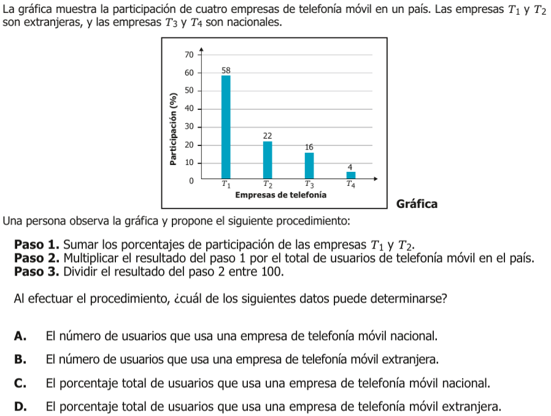

## 19.1 Análisis detallado del problema

### 19.1.1 Paso 1: Sumar los porcentajes de participación de las empresas $T_1$ y $T_2$

De la gráfica, tenemos: - $T_1 = 58\%$ - $T_2 = 22\%$

Sumamos estos porcentajes:
$$T_1 + T_2 =
58\% + 22\% = 80\%$$

### 19.1.2 Paso 2: Multiplicar el resultado del paso 1 por el total de usuarios de telefonía móvil en el país

Sea $U$ el total de usuarios de telefonía móvil en el país. Multiplicamos el resultado del paso 1 por $U$:
$$0.80 \times U$$

### 19.1.5 Conclusión

La opción correcta es:

**B. El número de usuarios que usa una empresa de telefonía móvil extranjera.**

Este es el dato que se puede determinar mediante el procedimiento propuesto.

## 19.2 Análisis de la Pregunta 2023-Matematicas-11-2-13, según SABER 11 ICFES

## 19.3 Nivel de Desempeño: 3

## 19.4 Competencia: Interpretación y Representación

- **Afirmación**: Comprende y transforma la información cuantitativa y esquemática presentada en distintos formatos
- **Evidencia**: Da cuenta de las características básicas de la información presentada en diferentes formatos como series, gráficas, tablas y esquemas

## 19.5 Componente: Numérico-Variacional

## 19.6 Estándar Asociado:

Interpreto y comparo resultados de estudios con información estadística provenientes de medios de comunicación.

## 19.7 ¿Qué evalúa?

La capacidad del estudiante para interpretar información presentada en un gráfico de barras y realizar operaciones aritméticas básicas con porcentajes para determinar valores específicos.

## 19.8 Respuesta Correcta: B

### 19.8.1 Justificación:

El procedimiento descrito permite calcular el número de usuarios de telefonía móvil extranjera:

1. $T_1 + T_2 = 58\% + 22\% = 80\%$
2. Si $U$ es el total de usuarios: $80\% \times U$
3. $\frac{80\% \times U}{100} = 0.8 \times U$

Este resultado representa el número total de usuarios que utilizan empresas extranjeras.

## 19.9 Motivos de las Opciones Incorrectas:

- **A**: El procedimiento no suma los porcentajes de empresas nacionales ($T_3$ y $T_4$)
- **C**: El procedimiento no calcula porcentajes de empresas nacionales
- **D**: El resultado es una cantidad absoluta, no un porcentaje

## 19.10 Contenidos Matemáticos Curriculares:

- **Álgebra y Cálculo**
- **Período**: 1
  - Números y Operaciones
    - Números racionales (porcentajes)
    - Operaciones aritméticas

## 19.11 Tipo: Genérico

## 19.12 Eje Axial Disciplinar:

Eje 1 - Univariadas: Interpretación de tablas y barras elementales

## 19.13 Tarea:

Interpretar un gráfico de barras y realizar operaciones con porcentajes para determinar el número de usuarios de telefonía móvil extranjera.

## 19.14 Grado: 11°

# 20 Pregunta 14

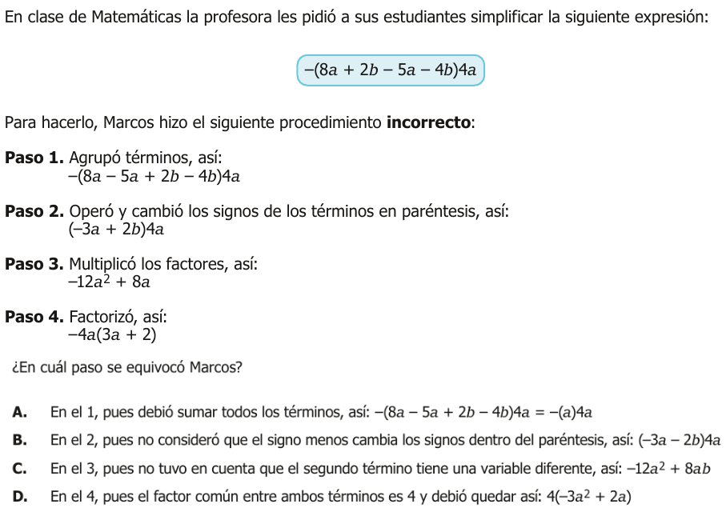

## 20.1 Análisis detallado del problema

Vamos a simplificar la expresión $-(8a + 2b - 5a - 4b)4a$ paso a paso y verificar cuál de las opciones (A, B, C o D) es la correcta.

## 20.2 Paso 1: Agrupar términos semejantes

Primero, agrupamos los términos semejantes dentro del paréntesis:

$$-(8a - 5a + 2b - 4b)4a$$

Simplificamos los términos dentro del paréntesis:

$$-(3a - 2b)4a$$

## 20.4 Paso 3: Multiplicar los factores

Multiplicamos los factores:

$$3a \cdot 4a - 2b \cdot 4a$$

## 20.7 Conclusión

La opción correcta es la **C**, ya que el error cometido por Marcos fue no tener en cuenta que el segundo término tiene una variable diferente, lo que resultó en la expresión $-12a^2 + 8ab$.

Por lo tanto, la respuesta correcta es:

$$\boxed{C}$$

## 20.8 Análisis de la Pregunta 2023-Matematicas-11-2-14, según SABER 11 ICFES

## 20.9 Nivel de Desempeño: 3

## 20.10 Competencia:

- Argumentación
  - Aprendizaje: Valida procedimientos y estrategias matemáticas utilizadas para dar solución a problemas
  - Evidencia: Argumenta a favor o en contra de un procedimiento para resolver un problema a la luz de criterios presentados o establecidos

## 20.11 Componente: Numérico-Variacional

## 20.12 Estándar Asociado:

Construyo expresiones algebraicas equivalentes a una expresión algebraica dada.

## 20.13 ¿Qué evalúa?

La capacidad para identificar errores en procedimientos algebraicos de factorización y operaciones con términos semejantes.

## 20.14 Respuesta Correcta: C

Justificación: El error está en el paso 3, donde Marcos no consideró que al multiplicar $(−3a + 2b)4a$ el segundo término debe quedar con la variable $b$, resultando en $-12a^2 + 8ab$ en lugar de $-12a^2 + 8a$.

## 20.15 Distractores:

- A: Incorrecta porque la agrupación de términos semejantes en el paso 1 está bien realizada
- B: Incorrecta porque el cambio de signos en el paso 2 está bien aplicado
- D: Incorrecta porque el error no está en la factorización final

## 20.16 Contenidos Matemáticos Curriculares:

- Álgebra y Cálculo
  - Período 2
    - Expresiones algebraicas
    - Operaciones con expresiones algebraicas

## 20.17 Tipo: No genérico

## 20.18 Eje Axial Disciplinar:

Términos Semejantes, Factorización Básica: Álgebra

## 20.19 Tarea:

Identificar el error en una secuencia de pasos algebraicos que involucra operaciones con términos semejantes y multiplicación de expresiones algebraicas.

## 20.20 Grado: 8° - 9°

# 21 Pregunta 15

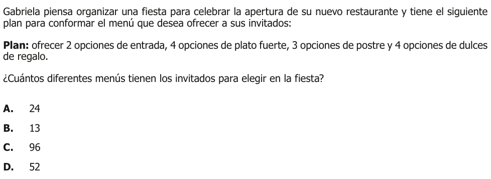

## 21.1 Análisis detallado del problema

Identificamos los elementos clave del problema: - 2 opciones de entrada - 4 opciones de plato fuerte - 3 opciones de postre - 4 opciones de dulces de regalo

## 21.2 Desarrollo Matemático

### 21.2.1 1. Estrategia de Solución

Para encontrar el total de menús diferentes posibles, debemos aplicar el principio multiplicativo de conteo, ya que: - Cada menú completo se forma seleccionando una opción de cada categoría - Las selecciones son independientes entre sí

### 21.2.2 2. Aplicación del Principio Multiplicativo

$\text{Total de menús} = \text{entradas} \times \text{platos fuertes} \times \text{postres} \times \text{dulces}$

Sustituyendo los valores:

$\text{Total} = 2 \times 4 \times 3 \times 4$

$\text{Total} = 96$

### 21.2.3 3. Verificación Lógica

- Cada invitado debe elegir:
  - Una de las 2 entradas
  - Uno de los 4 platos fuertes
  - Uno de los 3 postres
  - Uno de los 4 dulces de regalo

## 21.3 Conclusión

La respuesta correcta es C. 96 menús diferentes.

### 21.3.1 Justificación:

El resultado de 96 menús diferentes se obtiene porque cada invitado puede hacer su selección de manera independiente para cada categoría, y el principio multiplicativo nos permite calcular todas las combinaciones posibles mediante la multiplicación de las opciones disponibles en cada categoría.

## 21.4 Validación de Otras Opciones:

- A. 24: Este número es muy pequeño y no considera todas las combinaciones posibles
- B. 13: Este número es arbitrario y no refleja ninguna combinación lógica
- D. 52: Este número es inferior al total real de combinaciones posibles

## 21.5 Análisis de la Pregunta 2023-Matematicas-11-2-15, según SABER 11 ICFES

- Nivel de Desempeño: 3
- Competencia: Formulación y Ejecución
  - Aprendizaje: Frente a un problema que involucre información cuantitativa, plantea e implementa estrategias que lleven a soluciones adecuadas.
  - Evidencia: Ejecuta un plan de solución para un problema que involucra información cuantitativa o esquemática.
- Componente: Aleatorio
- Estándar Asociado: Resuelvo y planteo problemas usando conceptos básicos de conteo y probabilidad (combinaciones, permutaciones, espacio muestral, muestreo aleatorio, muestreo con reemplazo).
- ¿Qué evalúa?: La capacidad de aplicar el principio multiplicativo del conteo para determinar el número total de posibles combinaciones en una situación con múltiples opciones independientes.
- Respuesta Correcta: C. 96  
  Justificación: Al aplicar el principio multiplicativo del conteo, se multiplican las opciones disponibles de cada categoría: $2 \times 4 \times 3 \times 4 = 96$ menús diferentes posibles.
- Distractores:
  - A (24): Resulta de multiplicar incorrectamente solo algunas opciones.
  - B (13): Número arbitrario sin fundamento matemático.
  - D (52): Resultado de una operación incorrecta con los datos dados.
- Contenidos Matemáticos Curriculares:
  - Estadística
  - Período 3
    - Conjuntos, Combinatoria y Probabilidad
      - Principio de multiplicación
- Genérico: No
- Eje Axial Disciplinar: Eje 4 - Conjuntos, Casillas y Combinaciones
- Tarea: Aplicar el principio multiplicativo para calcular el total de combinaciones posibles en una situación de selección múltiple independiente.
- Grado: 11°

# 22 Pregunta 16

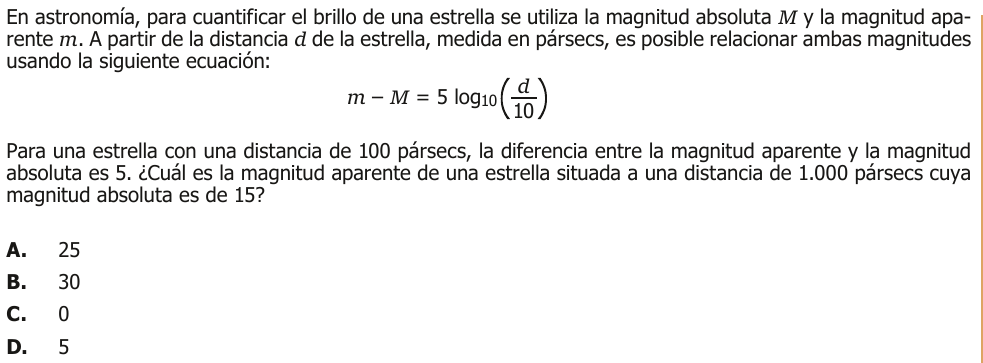

## 22.1 Análisis detallado del problema

En astronomía, para cuantificar el brillo de una estrella se utiliza la magnitud absoluta $M$ y la magnitud aparente $m$. A partir de la distancia $d$ de la estrella, medida en pársecs, es posible relacionar ambas magnitudes usando la siguiente ecuación:

$$m - M = 5 \log_{10} \left( \frac{d}{10}
\right)$$

Para una estrella con una distancia de 100 pársecs, la diferencia entre la magnitud aparente y la magnitud absoluta es 5. Vamos a resolver el problema paso a paso.

### 22.1.1 Paso 1: Determinar la fórmula para la magnitud aparente

La fórmula dada es:

$$m - M = 5 \log_{10} \left( \frac{d}{10}
\right)$$

### 22.1.2 Paso 2: Aplicar la fórmula con los datos dados

Queremos encontrar la magnitud aparente $m$ de una estrella situada a una distancia $d$ de 1.000 pársecs cuya magnitud absoluta $M$ es 15.

Sustituimos los valores en la fórmula:

$$m - 15 = 5 \log_{10} \left(
\frac{1000}{10} \right)$$

### 22.1.3 Paso 3: Simplificar la expresión dentro del logaritmo

Simplificamos la fracción dentro del logaritmo:

$$\frac{1000}{10} = 100$$

Entonces la ecuación se convierte en:

$$m - 15 = 5 \log_{10} (100)$$

### 22.1.4 Paso 4: Calcular el logaritmo

Sabemos que:

$$\log_{10} (100) = 2$$

Sustituimos este valor en la ecuación:

$$m - 15 = 5 \times 2$$

$$m - 15 = 10$$

### 22.1.5 Paso 5: Resolver para $m$

Sumamos 15 a ambos lados de la ecuación para encontrar $m$:

$$m = 10 + 15$$

$$m = 25$$

### 22.1.6 Conclusión

La magnitud aparente de la estrella es **25**. Por lo tanto, la opción correcta es:

**A. 25**

### 22.1.7 Análisis de la Pregunta 2023-Matematicas-11-2-16, según SABER 11 ICFES

- Nivel de Desempeño: 4
- Competencia: Formulación y Ejecución
  - Aprendizaje: Frente a un problema que involucre información cuantitativa, plantea e implementa estrategias que lleven a soluciones adecuadas
  - Evidencia: Ejecuta un plan de solución para un problema que involucra información cuantitativa o esquemática
- Componente: Numérico-Variacional
- Estándar Asociado: Utilizo las técnicas de aproximación en procesos infinitos numéricos
- ¿Qué evalúa?: La capacidad de aplicar una fórmula logarítmica en un contexto astronómico, realizando las sustituciones y operaciones algebraicas necesarias
- Respuesta Correcta: A (25)
- Justificación:  
  Al sustituir los valores dados ($d=1000$, $M=15$)  
  en la ecuación $m - M = 5 \log_{10} \left(\frac{d}{10}\right)$,  
  se obtiene $m - 15 = 5 \log_{10}(100)$.

  Como $\log_{10}(100)=2$,  
  entonces $m - 15 = 10$,  
  de donde $m = 25$
- Distractores:
  - B (30): Resultado de sumar incorrectamente 15 al valor 15 inicial
  - C (0): Resultado de ignorar el término logarítmico
  - D (5): Resultado de considerar solo el coeficiente 5 de la fórmula
- Contenidos Matemáticos Curriculares:
  - Álgebra y Cálculo
  - Período 4
    - Funciones logarítmicas
      - Propiedades básicas
- No genérico
- Eje Axial Disciplinar: Funciones II (Comportamientos Funcionales)
- Tarea: Resolver una ecuación logarítmica aplicada al contexto astronómico mediante sustitución y operaciones algebraicas
- Grado: 11°

# 23 Pregunta 17

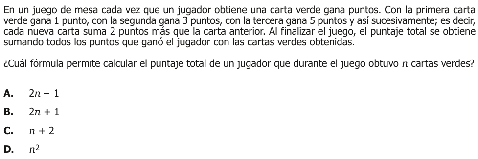

## 23.1 Análisis detallado del problema

La opción correcta es la **D. $n^2$**.

**Paso a paso:**

1. **Identificar la secuencia de puntos:** El enunciado describe una secuencia de puntos ganados con cada carta verde:
   - Primera carta: 1 punto
   - Segunda carta: 3 puntos
   - Tercera carta: 5 puntos
   - … y así sucesivamente.

   Podemos observar que los puntos ganados forman una secuencia de números impares.
2. **Encontrar una fórmula para los puntos de la *n*-ésima carta:** Analizando la secuencia, podemos deducir una fórmula para la cantidad de puntos ganados con la *n*-ésima carta verde. Observemos la relación:
   - Para la 1ª carta (n=1): 1 punto (2*1 - 1)
   - Para la 2ª carta (n=2): 3 puntos (2*2 - 1)
   - Para la 3ª carta (n=3): 5 puntos (2*3 - 1)
   - Para la *n*-ésima carta: $2n - 1$ puntos
3. **Calcular el puntaje total:** El puntaje total se obtiene sumando los puntos de todas las cartas verdes obtenidas. Si el jugador obtuvo *n* cartas verdes, necesitamos sumar los puntos de la primera carta hasta la *n*-ésima carta. Esto sería la suma de la siguiente serie:

   $1 + 3 + 5 + ... + (2n - 1)$

   Esta es la suma de los primeros *n* números impares.
4. **Aplicar la fórmula para la suma de los primeros *n* números impares:** Existe una fórmula matemática que establece que la suma de los primeros *n* números impares es igual a $n^2$.

   *Demostración (opcional):* Podemos ver esto como una serie aritmética donde el primer término es $a_1 = 1$, la diferencia común es $d = 2$, y el número de términos es $n$. La suma de una serie aritmética se calcula con la fórmula:

   $S_n = \frac{n}{2} [2a_1 + (n-1)d]$

   Sustituyendo los valores:

   $S_n = \frac{n}{2} [2(1) + (n-1)2]$ $S_n = \frac{n}{2} [2 + 2n - 2]$ $S_n = \frac{n}{2} [2n]$ $S_n = n^2$
5. **Verificar las otras opciones:**
   - **A. $2n - 1$:** Esta fórmula representa los puntos ganados con la *n*-ésima carta, no el puntaje total.
   - **B. $2n + 1$:** Esta fórmula no coincide con la secuencia de puntos ganados por las cartas.
   - **C. $n + 2$:** Esta fórmula tampoco coincide con la secuencia de puntos ganados ni con el puntaje total.

**Conclusión:** La fórmula que permite calcular el puntaje total de un jugador que obtuvo *n* cartas verdes es **$n^2$**. Cada carta sucesiva aporta un número impar de puntos, y la suma de los primeros *n* números impares es igual a $n^2$.

### 23.1.1 Análisis de la Pregunta 2023-Matematicas-11-2-17, según SABER 11 ICFES

- Nivel de Desempeño: 4
- Competencia: Interpretación y Representación
  - Afirmación: Comprende y transforma la información cuantitativa y esquemática presentada en distintos formatos
  - Evidencia: Da cuenta de las características básicas de la información presentada en diferentes formatos
- Componente: Numérico-Variacional
- Estándar Asociado: Reconozco y generalizo propiedades de las relaciones entre números racionales y de las operaciones entre ellos en diferentes contextos
- ¿Qué evalúa?: La capacidad para identificar patrones numéricos y traducirlos a una expresión algebraica que generaliza la suma de una secuencia aritmética de números impares
- Respuesta Correcta: D. $n^2$

Justificación:

La secuencia de puntos forma una progresión aritmética de números impares: 1, 3, 5, 7, …, $(2n-1)$

La suma de los primeros $n$ números impares viene dada por la fórmula $n^2$, lo que se puede verificar:

- Para n=1: $1 = 1^2$
- Para n=2: $1 + 3 = 2^2$
- Para n=3: $1 + 3 + 5 = 3^2$
- Para n=4: $1 + 3 + 5 + 7 = 4^2$

Motivos de las opciones incorrectas:  
- A. $2n-1$: Representa el último término de la secuencia, no la suma  
- B. $2n+1$: Fórmula incorrecta que no corresponde al patrón  
- C. $n+2$: No representa el comportamiento cuadrático de la suma

- Contenidos Matemáticos Curriculares:
  - Álgebra y Cálculo
  - Período 2
    - Expresiones algebraicas
      - Operaciones con expresiones algebraicas
- No genérico
- Eje Axial Disciplinar: Eje 3 - Función Lineal, Generalizaciones y Grado 2
- Tarea: Identificar la expresión algebraica que generaliza la suma de una secuencia aritmética de números impares
- Grado: 11°

# 24 Pregunta 18

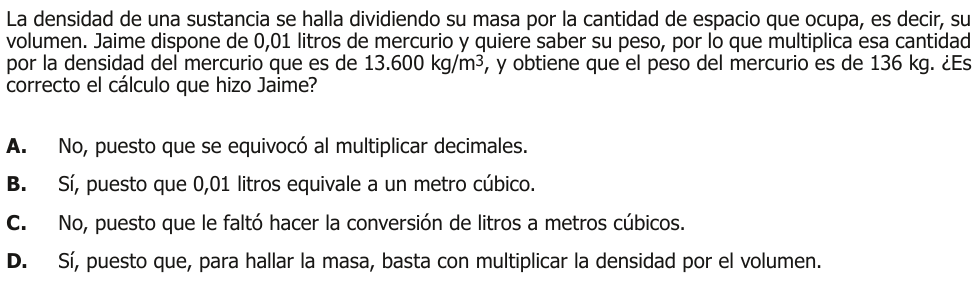

## 24.1 Análisis detallado del problema

Para resolver este problema, es importante entender cómo se calcula la masa de una sustancia a partir de su volumen y densidad. La fórmula para calcular la masa es:

$$\text{masa} = \text{densidad} \times
\text{volumen}$$

Dado que Jaime dispone de 0,01 litros de mercurio y la densidad del mercurio es de $13.600 \, \text{kg/m}^3$, necesitamos convertir el volumen a metros cúbicos ($\text{m}^3$) para que las unidades coincidan.

Vamos a analizar cada opción paso a paso:

### 24.1.1 Opción A

**No, puesto que se equivocó al multiplicar decimales.**

Esta opción sugiere que Jaime se equivocó en la multiplicación de decimales. Sin embargo, el error principal no está en la multiplicación de decimales, sino en la conversión de unidades.

### 24.1.2 Opción B

**Sí, puesto que 0,01 litros equivale a un metro cúbico.**

Esta opción es incorrecta. 0,01 litros no equivale a un metro cúbico. La conversión correcta es:

$$1 \, \text{litro} = 0,001 \, \text{m}^3$$

Por lo tanto, 0,01 litros es:

$$0,01 \, \text{litros} = 0,01 \times
0,001 \, \text{m}^3 = 0,00001 \, \text{m}^3$$

### 24.1.3 Opción C

**No, puesto que le faltó hacer la conversión de litros a metros cúbicos.**

Esta es la opción correcta. Jaime no realizó la conversión de litros a metros cúbicos, lo cual es necesario para que las unidades coincidan en la fórmula de la masa.

### 24.1.4 Opción D

**Sí, puesto que, para hallar la masa, basta con multiplicar la densidad por el volumen.**

Esta opción es incorrecta porque, aunque la fórmula para hallar la masa es correcta, Jaime no realizó la conversión de unidades necesaria.

### 24.1.5 Resolución correcta

1. **Convertir el volumen de litros a metros cúbicos:**

$$0,01 \, \text{litros} = 0,01 \times
0,001 \, \text{m}^3 = 0,00001 \, \text{m}^3$$

2. **Calcular la masa usando la densidad y el volumen convertido:**

$$\text{masa} = \text{densidad} \times
\text{volumen}$$
$$\text{masa} =
13.600 \, \text{kg/m}^3 \times 0,00001 \, \text{m}^3$$
$$\text{masa} = 0,136 \, \text{kg}$$

Por lo tanto, el peso correcto del mercurio es 0,136 kg, no 136 kg.

### 24.1.6 Conclusión

La opción correcta es la **C**. ‘Jaime se equivocó porque no realizó la conversión de litros a metros cúbicos’.

### 24.1.7 Análisis de la Pregunta 2023-Matematicas-11-2-18, según SABER 11 ICFES

- Nivel de Desempeño: 3
- Competencia: Argumentación
  - Aprendizaje: Valida procedimientos y estrategias matemáticas utilizadas para dar solución a problemas
  - Evidencia: Argumenta a favor o en contra de un procedimiento para resolver un problema a la luz de criterios presentados o establecidos
- Componente: Numérico-Variacional
- Estándar Asociado: Justifico la pertinencia de utilizar unidades de medida estandarizadas en situaciones tomadas de distintas ciencias.
- ¿Qué evalúa?: La capacidad para identificar errores en procedimientos que involucran conversión de unidades de volumen y cálculos con densidad.
- Respuesta Correcta: C
- Justificación: El error está en no convertir 0,01 litros a metros cúbicos antes de multiplicar por la densidad. La conversión correcta sería:

$0,01 \text{ L} = 0,01 \times 0,001 \text{ m}^3 = 0,00001 \text{ m}^3$

Luego: $\text{masa} = \text{densidad} \times \text{volumen}$ $\text{masa} = 13.600 \text{ kg/m}^3 \times 0,00001 \text{ m}^3 = 0,136 \text{ kg}$

- Distractores:
  - A: Asume que el error está en la multiplicación de decimales
  - B: Asume incorrectamente la equivalencia entre litros y metros cúbicos
  - D: Aunque la fórmula es correcta, ignora la necesidad de conversión de unidades
- Contenidos Matemáticos Curriculares:
  - Álgebra y Cálculo
  - Período 1
    - Números y Operaciones
      - Uso de números y operaciones en la resolución de problemas
- Genérico: Sí
- Eje Axial Disciplinar: Eje 1 - Paso 1, Paso 2: Seguimiento de instrucciones
- Tarea: Validar la pertinencia de un procedimiento de cálculo que involucra conversión de unidades y densidad
- Grado: 9° - 11°

# 25 Pregunta 19

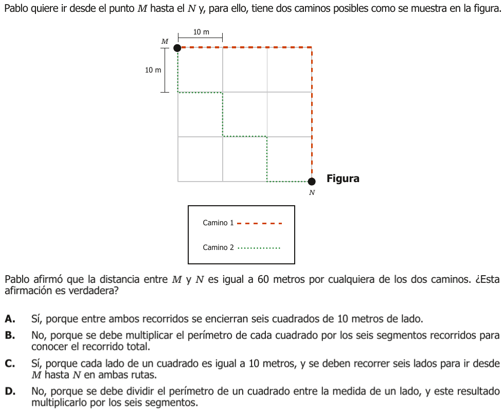

## 25.1 Análisis detallado del problema

Pablo quiere ir desde el punto $M$ hasta el $N$ y tiene dos caminos posibles como se muestra en la figura. Pablo afirmó que la distancia entre $M$ y $N$ es igual a 60 metros por cualquiera de los dos caminos. Vamos a verificar esta afirmación paso a paso.

## 25.2 Análisis de las Opciones

### 25.2.1 Opción A

**Afirmación:** Sí, porque entre ambos recorridos se encierran seis cuadrados de 10 metros de lado.

**Análisis:** Esta opción sugiere que la distancia total es 60 metros porque se encierran seis cuadrados de 10 metros de lado. Sin embargo, esto no considera el recorrido específico de cada camino.

### 25.2.2 Opción B

**Afirmación:** No, porque se debe multiplicar el perímetro de cada cuadrado por los seis segmentos recorridos para conocer el recorrido total.

**Análisis:** Esta opción sugiere que se debe considerar el perímetro de cada cuadrado multiplicado por los seis segmentos. Esto no es correcto porque el perímetro de un cuadrado no es relevante para calcular la distancia total recorrida.

### 25.2.3 Opción C

**Afirmación:** Sí, porque cada lado de un cuadrado es igual a 10 metros, y se deben recorrer seis lados para ir desde $M$ hasta $N$ en ambas rutas.

**Análisis:** Esta opción es correcta. Vamos a verificarlo:

   Total: $10 + 10 + 10 + 10 + 10 + 10 = 60$ metros.

### 25.2.4 Opción D

**Afirmación:** No, porque se debe dividir el perímetro de un cuadrado entre la medida de un lado, y este resultado multiplicarlo por los seis segmentos.

**Análisis:** Esta opción sugiere dividir el perímetro de un cuadrado entre la medida de un lado y luego multiplicar por los seis segmentos. Esto no es correcto porque el perímetro de un cuadrado no es relevante para calcular la distancia total recorrida.

## 25.3 Conclusión

La opción correcta es la **C**. Cada lado de un cuadrado es igual a 10 metros, y se deben recorrer seis lados para ir desde $M$ hasta $N$ en ambas rutas, resultando en una distancia total de 60 metros para cualquiera de los dos caminos.

$$\boxed{C}$$

### 25.3.1 Análisis de la Pregunta 2023-Matematicas-11-2-19, según SABER 11 ICFES

- Nivel de Desempeño: 3
- Competencia: Argumentación
  - Afirmación: Valida procedimientos y estrategias matemáticas utilizadas para dar solución a problemas
  - Evidencia: Plantea afirmaciones que sustentan o refutan una interpretación dada a la información disponible
- Componente: Geométrico-Métrico
- Estándar Asociado: Generalizo procedimientos de cálculo válidos para encontrar el área de regiones planas y el volumen de sólidos.
- ¿Qué evalúa?: La capacidad para validar una afirmación sobre distancias en una cuadrícula usando propiedades geométricas básicas.
- Respuesta Correcta: C, porque cada lado del cuadrado mide 10 metros y en ambas rutas se deben recorrer exactamente 6 lados para ir de M a N, resultando en 60 metros totales.

Distractores:

- A: Confunde el área encerrada con la distancia recorrida
- B: Aplica incorrectamente el concepto de perímetro
- D: Realiza operaciones sin sentido geométrico

Contenidos Matemáticos Curriculares:

- Geometría
- Período 1
  - Geometría Básica
    - Medición de distancias
    - Trayectorias en el plano cartesiano

Tipo: No genérico

Eje Axial Disciplinar: Complementarios, Suplementarios y Operaciones Proporcionales

Tarea: Validar una afirmación sobre la igualdad de distancias entre dos puntos siguiendo diferentes trayectorias rectilíneas en una cuadrícula.

Grado sugerido: 9° - 11°

# 26 Pregunta 20

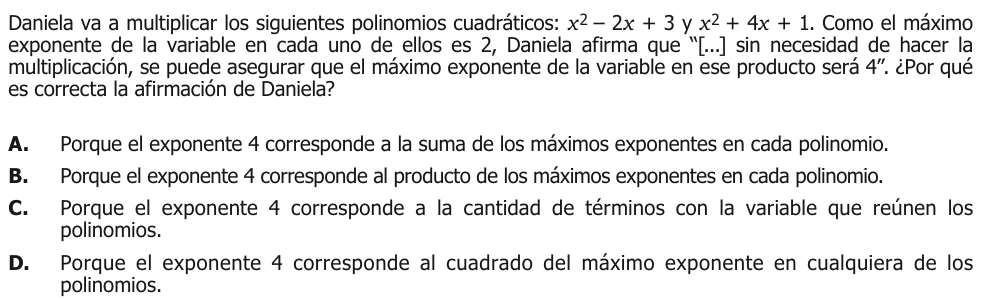

## 26.1 Análisis detallado del problema

Tenemos dos polinomios cuadráticos:

- $P_1(x) = x^2 - 2x + 3$
- $P_2(x) = x^2 + 4x + 1$

Daniela afirma que el máximo exponente en el producto será 4, sin necesidad de realizar la multiplicación.

## 26.2 Análisis Paso a Paso

1. Al multiplicar dos polinomios, los exponentes de los términos se suman. Por ejemplo:
   - $(x^a)(x^b) = x^{a+b}$
2. En este caso, el máximo exponente en cada polinomio es 2, entonces:
   - Máximo exponente de $P_1(x)$ = 2
   - Máximo exponente de $P_2(x)$ = 2
3. Al multiplicar los términos con los exponentes más altos:
   - $(x^2)(x^2) = x^{2+2} = x^4$
4. Por lo tanto, el máximo exponente en el producto será:
   - 2 + 2 = 4

## 26.3 Conclusión

La respuesta correcta es la opción **A**: “Porque el exponente 4 corresponde a la suma de los máximos exponentes en cada polinomio.”

## 26.4 Justificación de por qué las otras opciones son incorrectas:

- **B** es incorrecta porque sugiere multiplicar los exponentes (2 × 2 = 4), lo cual no es la regla correcta.
- **C** es incorrecta porque el número de términos no determina el exponente máximo.
- **D** es incorrecta porque no se eleva al cuadrado el exponente máximo.

## 26.5 Principio Matemático General

En el álgebra de polinomios, cuando multiplicamos dos términos:  
$x^m \cdot x^n = x^{m+n}$

Este principio fundamental explica por qué el máximo exponente en el producto será la suma de los exponentes máximos de los polinomios factores.

### 26.5.1 Análisis de la Pregunta 2023-Matematicas-11-2-20, según SABER 11 ICFES

- Nivel de Desempeño: 3
- Competencia: Argumentación
  - Aprendizaje: Valida procedimientos y estrategias matemáticas utilizadas para dar solución a problemas
  - Evidencia: Plantea afirmaciones que sustentan o refutan una interpretación dada a la información disponible
- Componente: Numérico-Variacional
- Estándar Asociado: Utilizo las propiedades de los números reales para justificar procedimientos y diferentes representaciones de subconjuntos de ellos
- ¿Qué evalúa?: La comprensión de las propiedades de los exponentes al multiplicar polinomios

## 26.6 Respuesta Correcta y Justificación

La opción correcta es A: “Porque el exponente 4 corresponde a la suma de los máximos exponentes en cada polinomio”

### 26.6.1 Justificación

Al multiplicar dos polinomios $P_1(x) = x^2 - 2x + 3$ y $P_2(x) = x^2 + 4x + 1$:

1. Los exponentes se suman al multiplicar términos: $x^a \cdot x^b = x^{a+b}$
2. El mayor exponente en cada polinomio es 2
3. Por tanto: $x^2 \cdot x^2 = x^{2+2} = x^4$

### 26.6.2 Distractores

B: Incorrecta - Confunde suma con producto de exponentes C: Incorrecta - Relaciona erróneamente cantidad de términos con exponente máximo D: Incorrecta - Malinterpreta las reglas de exponentes

## 26.7 Contenidos Matemáticos Curriculares

- Álgebra y Cálculo
- Período: 2
  - Álgebra
    - Operaciones con expresiones algebraicas
- No genérico
- Eje Axial Disciplinar: Términos Semejantes, Factorización Básica: Álgebra
- Tarea: Justificar el exponente máximo resultante al multiplicar dos polinomios usando las propiedades de los exponentes
- Grado: 8° - 9°

# 27 Referencias